# Simple Regression & Exploratory Analysis

Pablo Rodriguez

1/17/2020

# Restoring cadmium contaminated soils using *Eremochloa ophiuroideas*

It was of interest to study the detoxifying capacity of *Eremochloa ophiuroides* in Cd contaminated soils.

### Experimental Design:

20 pots of soil with this grass were assigned 5 different dosis of Cd (60, 120, 180, 240 and 300 mg Cd per kg)

Each dose of Cd was assigned 4 pots.

After 36 days in the greenhouse accumalated Cd was measured in the plant as: Cd per kg of dried plant weight.

Model Description:

A linear relationship is suspected. The Response Variable (RV) is accumalated Cd. The Explanatory Variable (EV) which is Cd dosage is the deterministic part of the analysis. All statistic models have an error (E) asociated with them and is called the stocastic part of the analysis and it contemplates the: 1) inherent aleatory process 2) The effect of other EV not included in the model and 3) measuring error. This error is assigned a probability distribution and in this case it is assigned a normal distribution since the RV is a continuos variable.

### Firstly

I will view the data and observe the mean, median and minimums and maximums.

```r
Dosage = c(
  60, 60, 60, 60,
  120, 120, 120, 120,
  180, 180, 180, 180,
  240, 240, 240, 240,
  300, 300, 300, 300)

CdStalk = c(
  23.2, 16.2, 52.7, 29.1,
  52.5, 45.7, 52.9, 84.9,
  123.5, 106.9, 123.9, 145.7,
  166.8, 165.9, 184.3, 157,
  208.4, 189.9, 217.7, 193.2
)

CdRoot = c(
  104.6, 156, 114.9, 176.9,
  258.4, 340.9, 205.3, 366.8,
  457.5, 540.8, 472.5, 294.3,
  612.7, 789.6, 622.9, 562.6,
  988.9, 1067.1, 959.6, 962.9
)
Cd = data.frame(Dosage, CdStalk, CdRoot)
Cd
```

```
##    Dosage CdStalk CdRoot
## 1      60    23.2  104.6
## 2      60    16.2  156.0
## 3      60    52.7  114.9
## 4      60    29.1  176.9
## 5     120    52.5  258.4
## 6     120    45.7  340.9
## 7     120    52.9  205.3
## 8     120    84.9  366.8
## 9     180   123.5  457.5
## 10    180   106.9  540.8
## 11    180   123.9  472.5
## 12    180   145.7  294.3
## 13    240   166.8  612.7
## 14    240   165.9  789.6
## 15    240   184.3  622.9
## 16    240   157.0  562.6
## 17    300   208.4  988.9
## 18    300   189.9 1067.1
## 19    300   217.7  959.6
## 20    300   193.2  962.9
```

```r
summary(Cd)
```

```
##      Dosage       CdStalk           CdRoot
##  Min.   : 60   Min.   : 16.20   Min.   : 104.6
##  1st Qu.:120   1st Qu.: 52.65   1st Qu.: 245.1
##  Median :180   Median :123.70   Median : 465.0
##  Mean   :180   Mean   :117.02   Mean   : 502.8
##  3rd Qu.:240   3rd Qu.:171.18   3rd Qu.: 664.6
##  Max.   :300   Max.   :217.70   Max.   :1067.1
```

```r
#Libraries used

library(ggplot2)
library(car)
library(ggpubr)
```

```r
DispGraph = function(df,x,y) {
  x = x
  y = y
  p = ggplot(df, aes(x = x, y = y)) +
    geom_point() +
    geom_abline(slope = 0, intercept = 0) +
    labs(x = "Predicted", y = "Standard Error")

  return(p)
}

ValidGraph = function(df,x,y) {
  x = x
  y = y
  p = ggplot(df, aes(x = x, y = y)) +
    geom_point() +
    geom_abline(slope = 1, intercept = 0) +
    labs(x = "Ajusted", y = "Cd")
}

ResponseGraph = function(df, x, y) {
  x = x
  y = y
  p = ggplot(df, aes(x = x, y = y))+
    geom_boxplot(aes(color = Dosage)) +
    labs(x = "Dosage", y = "Pearson Residues") +
    theme(legend.position = "none")
}

ggQQ = function(LM) # argument: a linear model
{
  y = quantile(LM$resid[!is.na(LM$resid)], c(0.25, 0.75))
  x = qnorm(c(0.25, 0.75))
  slope = diff(y)/diff(x)
  int = y[1L] - slope * x[1L]
  p = ggplot(LM, aes(sample = resid(LM))) +
    stat_qq(alpha = 0.5) +
    geom_abline(slope = slope, intercept = int, color="blue")

  return(p)
}
```

### Visualizing the data

In order to observe any relationships between my Response Variable (RV) (Cd in grass stalk) and my Explanatory Variabel (EV) I will graph the data and I will be using ggplot:

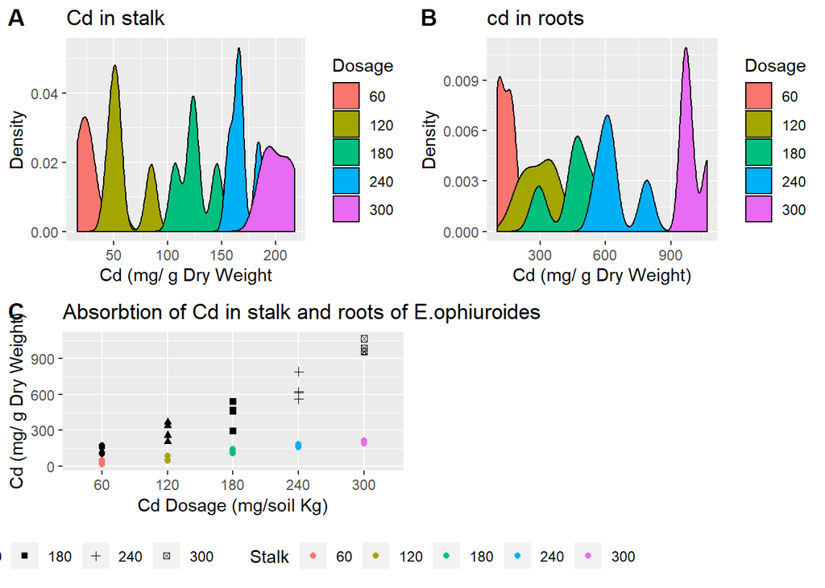

```r
Cd$Dosage = as.factor(Cd$Dosage)
CdStalkDens = ggplot() +
  geom_density(data = Cd, aes(x = CdStalk, fill = Cd$Dosage)) +
  labs(x = "Cd (mg/ g Dry Weight", y = "Density", fill = "Dosage", title = "Cd in stalk")

CdRootDens = ggplot() +
  geom_density(data = Cd, aes(x = CdRoot, fill = Cd$Dosage)) +
  labs(x = "Cd (mg/ g Dry Weight)", y = "Density", fill = "Dosage", title = "cd in roots")

gCd = ggplot() +
  geom_point(data = Cd, aes(x = Cd$Dosage, y = Cd$CdStalk, colour = Cd$Dosage)) +
  labs(x = "Cd Dosage (mg/soil Kg)" , y = "Cd (mg/ g Dry Weight)", title = "Absorbtion of Cd in stalk and roots of E.ophiuroides",
       colour = "Stalk", shape = "Root") +
  geom_point(data = Cd, aes(x = Dosage, y = Cd$CdRoot, shape = Cd$Dosage)) +
  theme(legend.position = "bottom")

ggarrange(CdStalkDens, CdRootDens, gCd,
          labels = c("A", "B", "C"))
```

Y$_{i}$ = $\hat{\beta}$$_{0}$ + $\hat{\beta}$$_{1}$*$X_{i}$ + $\varepsilon$$_{i}$

Where Y is the RV

$\hat{\beta}$$_{0}$ is the intercept of the model

$\hat{\beta}$$_{1}$ is the slope

$X_{n}$ is the EV

and $\varepsilon$$_{i}$ is the error associated with the model.

```r
model1 = lm(Cd$CdStalk ~ Cd$Dosage, data = Cd)

model2 = lm(Cd$CdRoot ~ Dosage, data = Cd)
```

The values of the estimated coefficients are meaningles if the assumptions of the model are not corroborated

### Assumptions:

#### X is measured without error, Values are determined by the person.

#### Independent Observations, meaning the value of one observation is not influenced by another observation. In other words there shouldn’t be correlation between values.

In order to check the independence of the observations it is necessary to estimate the error of the model:

```r
errorm1 = resid(model1) ##residues
errorm2 = resid(model2)
standard_errorm1 = rstandard(model1) ##standard residues
standard_errorm2 = rstandard((model2))
predictedm1  = predict(model1) #predicted residues
predictedm2 = predict(model2)

res = cbind(Cd$Dosage, Cd$CdStalk, Cd$CdRoot, errorm1, errorm2, round(standard_errorm1,2), round(standard_errorm2, 2), predictedm1, predictedm2)
colnames(res) = c("Dosage", "CdStalk", "CdRoots", "Error_m1", "Error_m2", "Stan_Error_m1", "Stan_Error_m2", "Predicted_m1", "Predicted_m2")
res = as.data.frame(res)
```

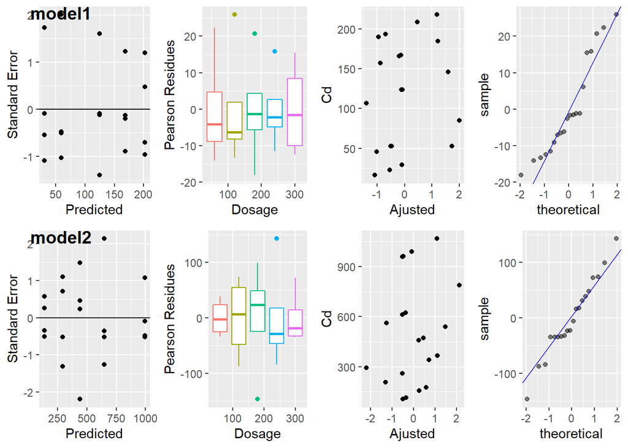

```r
##Predicted versus Standard Error
DGm1 = DispGraph(Cd, predictedm1, standard_errorm1)
DGm2 = DispGraph(Cd, predictedm2, standard_errorm2)

#Response Graph
RGm1 = ResponseGraph(Cd, Dosage, errorm1)
RGm2 = ResponseGraph(Cd, Dosage, errorm2)

#Validation Graph
VGm1 = ValidGraph(Cd, standard_errorm1, CdStalk)
VGm2 = ValidGraph(Cd, standard_errorm2, CdRoot)

#QQplot
QQm1 = ggQQ(model1)
QQm2 = ggQQ(model2)

ggarrange(DGm1, RGm1, VGm1, QQm1, DGm2, RGm2, VGm2, QQm2,
          ncol = 4, nrow = 2, labels = c("model1", "", "", "", "model2"))
```

In statistics Homoscedasticity is the assumption that the error of the data is distributed normally. I will conduct Shapiro’s Test to test this. To test the Homogeinity of Variance I will conduct a Levene’s Test. Homogeneity of Variance is an assumption that **cannot** not be met, unlike Homoscedasticity that cannot be met but still inform correct statistical values.

```r
Shap.Testm1 = shapiro.test(errorm1)
Shap.Testm2 = shapiro.test(errorm2)

Homo.Testm1 = leveneTest(Cd$CdStalk,Cd$Dosage)
Homo.Testm2 = leveneTest(Cd$CdRoot, Cd$Dosage)

tests = cbind("p-value", round(Shap.Testm1$p.value,3), round(Homo.Testm1$`Pr(>F)`,3), round(Shap.Testm2$p.value,3), round(Homo.Testm2$`Pr(>F)`,3))
colnames(tests) = c("", "Shapiro m1", "Levene m1", "Shapiro m2", "Levene m2")
tests[1,]
```

```
##            Shapiro m1  Levene m1 Shapiro m2  Levene m2
##  "p-value"    "0.045"    "0.988"    "0.892"    "0.797"
```

For model 1 I can reject the Normality hypothesis since Shapiro m1 p-val < 0.5. But this assumption can be violated if Homoscedasticity is met: Levene’s Test suggests there is no need to reject the null hypothesis, therefore homoscedasticity “is met”. Luckily for model 2 both assumptions are met.

I can continue to work with both models. I will now graph the linear model:

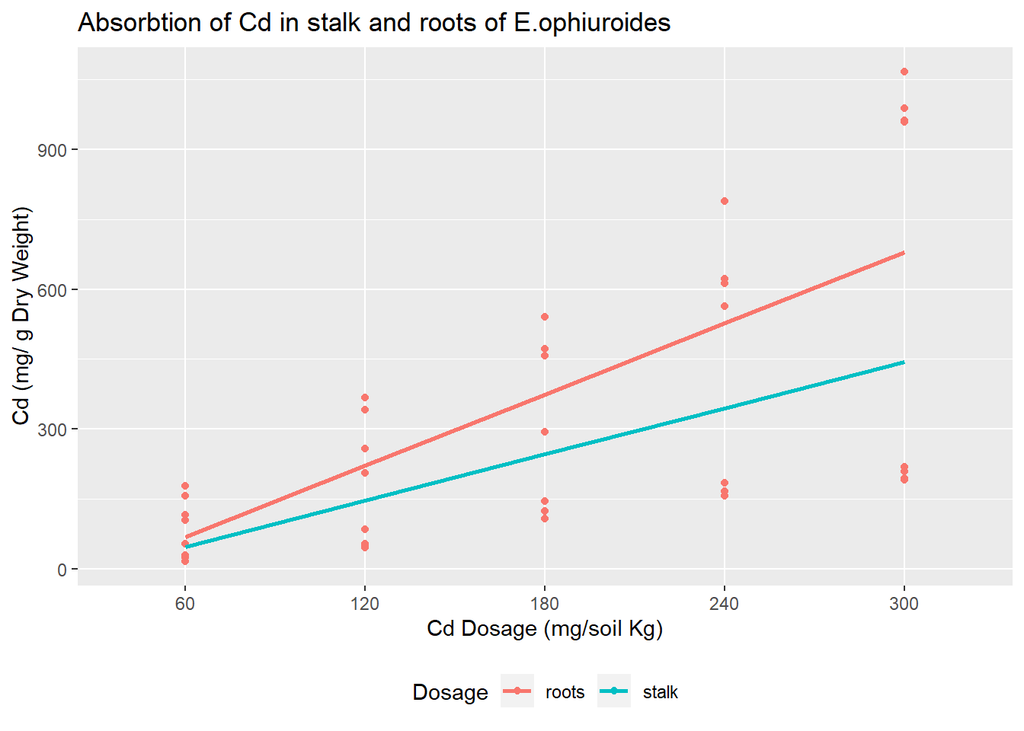

```r
place = c(
   rep("stalk", 60), rep("roots", 60)
)
CdPlant = c(  23.2, 16.2, 52.7, 29.1,
  52.5, 45.7, 52.9, 84.9,
  123.5, 106.9, 123.9, 145.7,
  166.8, 165.9, 184.3, 157,
  208.4, 189.9, 217.7, 193.2,
  104.6, 156, 114.9, 176.9,
  258.4, 340.9, 205.3, 366.8,
  457.5, 540.8, 472.5, 294.3,
  612.7, 789.6, 622.9, 562.6,
  988.9, 1067.1, 959.6, 962.9
)

Cd = data.frame(Dosage, CdPlant, place)
Cd$Dosage = as.factor(Cd$Dosage)
Cd$place = as.factor(Cd$place)
gCd = ggplot(data = Cd, aes(x = Cd$Dosage, y = CdPlant, group = place, colour = place)) +
  geom_point(aes(colour = place)) +
  geom_smooth(method = "lm", se = FALSE)+
  labs(x = "Cd Dosage (mg/soil Kg)" , y = "Cd (mg/ g Dry Weight)", title = "Absorbtion of Cd in stalk and roots of E.ophiuroides",
       colour = "Dosage", group = "Place") +
  theme(legend.position = "bottom")

gCd
```

```r
#Determination coefficient
R2m1 = summary(model1)$r.squared
R2m2 = summary(model2)$r.squared
slope = summary(model1)$intercept
```

```r
sumModel1 = summary(model1)$coefficients
sumModel1
```

```
##              Estimate Std. Error   t value     Pr(>|t|)
## (Intercept)      30.3   7.462819  4.060128 1.025981e-03
## Cd$Dosage120     28.7  10.554020  2.719343 1.583223e-02
## Cd$Dosage180     94.7  10.554020  8.972884 2.038625e-07
## Cd$Dosage240    138.2  10.554020 13.094537 1.299671e-09
## Cd$Dosage300    172.0  10.554020 16.297108 5.987363e-11
```

```r
sumModel2 = summary(model2)$coefficients
seperate = "Model2"
sumModels = rbind(sumModel1, seperate, sumModel2)

sumModels
```

```
##              Estimate  Std. Error         t value
## (Intercept)  "30.3"    "7.46281894907459" "4.06012797667526"
## Cd$Dosage120 "28.7"    "10.5540197713162" "2.7193430201828"
## Cd$Dosage180 "94.7"    "10.5540197713162" "8.97288446032443"
## Cd$Dosage240 "138.2"   "10.5540197713162" "13.094536773145"
## Cd$Dosage300 "172"     "10.5540197713162" "16.2971079955206"
## seperate     "Model2"  "Model2"           "Model2"
## (Intercept)  "138.1"   "38.6425316199651" "3.57378241565957"
## Dosage120    "154.75"  "54.6487923013858" "2.83171857022129"
## Dosage180    "303.175" "54.6487923013857" "5.54769807771786"
## Dosage240    "508.85"  "54.6487923013858" "9.31127621620097"
## Dosage300    "856.525" "54.6487923013858" "15.6732649328516"
##              Pr(>|t|)
## (Intercept)  "0.00102598062545739"
## Cd$Dosage120 "0.0158322304957625"
## Cd$Dosage180 "2.03862460164762e-07"
## Cd$Dosage240 "1.29967112342801e-09"
## Cd$Dosage300 "5.98736269959037e-11"
## seperate     "Model2"
## (Intercept)  "0.00277070891439885"
## Dosage120    "0.0126246491584542"
## Dosage180    "5.58415657564381e-05"
## Dosage240    "1.26697724931974e-07"
## Dosage300    "1.04284588000491e-10"
```